# Dengue

Lucas Caballero

2026-06-21

## CASO DE ESTUDIO: DENGUE EN EL CONURBANO BONAERENSE

# Introducción:

El dengue configura un problema de salud pública considerable; es una enfermedad viral que se trasmite a traves de los mosquitos del género Aedes Aegypti. Según la Organización Panamericana de la Salud (OPS), el año 2024 fue donde se registraron la mayor cantidad de casos en la Región de las Américas con 13 millones de casos, notificados en 50 países con una tasa de letalidad de 0,063% (8186 casos fatales) con co-circulación de los cuatro serotipos de dengue (DENV-1 a DENV-4)1 (Ministerio de Salud de la Nación, 2025-2026).

En el caso de la Argentina, tuvieron las epidemias más importantes durante los años 2023 y 2024; donde se registraron la mayor cantidad de casos confirmados y fallecidos por esta problemática. Sumado a que durante el año 2023 la transmisión del virus sucedió durante todo el año en el territorio nacional; además de cuestiones adyacentes como la circulación simultáneas de otros serotipos del virus, que complejizan el cuadro de resolución (Ministerio de Salud de la Nación, 2025-2026).

Ahora bien, cuando se cubre un análisis sobre el Conurbano Bonaerense, es entrar en una compleja categoría y remite a la convergencia de narrativas y prácticas (administrativas, técnicas, políticas, sociales y económicas) que contribuyeron a su construcción como una unidad específica y en oposición a la Ciudad de Buenos Aires, incorporando a la vida cotidiana, conceptos propios del urbanismo, para expresar mayormente con evocaciones negativas una realidad urbana social, compleja y dinámica (Atlas Conurbano, 2016).

La extensión territorial prosigue con la categoría “24 partidos del GBA” (INDEC) que refiere al área que rodea a la Ciudad de Buenos Aires y que forma parte del aglomerado “Gran Buenos Aires”, que incluye, conjuntamente, a la Ciudad Autónoma de Buenos Aires y los mismos 24 partidos (Atlas Conurbano, 2016). Sin embargo, al categorizarse como Conurbano (específicamente), y por sus concepciones previamente descritas, esta área no comprende a la Ciudad Autónoma de Buenos Aires.

Por ello, es necesario interiorizarse en la problemática de casos de dengue, en gran parte del aglomerado que conforma el “Conurbano”. Se enmarcará una investigación sobre cuánto incide la densidad poblacional de cada uno de los 24 municipios de esta área geográfica sobre los casos confirmados de Dengue existente, durante el período de 2025 a junio de 2026.

# Problema:

¿La tasa de incidencia sobre casos del dengue aumenta en los municipios más densamente poblados del Conurbano Bonaerense según los datos del Registro del Sistema Nacional de Vigilancia de la Salud 2.0 (2025-2026)?

# Hipótesis:

Los 5 municipios más densamente poblados del Conurbano Bonaerense (Lanús, Vicente López, Tres de Febrero, General San Martín, Lomas de Zamora) revisten las más altas tasas de incidencia de casos de dengue durante el período 2025-2026.

# Objetivo:

Analizar la densidad poblacional de los municipios (o departamentos) que conforman el Conurbano Bonaerense y, si con ello refleja, una mayor tasa de incidencia en casos confirmados de dengue.

# Metodología:

Este análisis se compone originalmente de dos datasets no espaciales: el correspondiente a los casos del dengue, que dedica su información a una representación de tabla epidemiológica entre los años 2025 y 2026; el otro dataset responde a un reporte de datos demográficos que derivan del Censo 2022, que describen datos estadísticos (es interesante que contiene datos georreferenciales, pero no por ello son estrictamente un dataset espacial). Sin embargo, más adelante prosiguiendo con la investigación, se recurrió a la utilización de la librería “geoAr” que permite proporcionar distintas geometrías, entre las que necesitamos sobre los 24 municipios del Conurbano Bonaerense.

En esta parte del trabajo se utilizaron distintas librerías como tidyverse y dplyr que nos permite las modificaciones pertinentes a los datasets cargados. Con ello logramos conseguir la unión de los datasets según variables comunes como el caso de los códigos de provincia y de departamento, que son estrictamente necesarios para unir especificaciones poblacionales, como conseguir la densidad poblacional o la tasa de incidencia de casos de dengue. Previo a seguir con los mapas se decidió transformar la latitud y longitud del centroide a una geometría mediante la librería sf y estar atento a transformarla a POSGAR 2007/Faja 5 (cod. 22185), concibiendo así la noción espacial esperada.

En la siguiente etapa del trabajo, posterior a la unión de los dos datasets, se sumó la unión de este nuevo dataset con el mapa que brinda esta librería, siendo así de carácter espacial. Aquí es necesario utilizar la librería geoAr que nos brinda el mapa de la provincia de Buenos Aires, dividido de departamentos; mediante el uso de la librería sf utilizamos algunas funciones para evitar geometrías inválidas o rotas y, posteriormente, la generación de diferentes mapas (utilzando esta librería, como así también mediante ggplot2 o leaflet -que nos proporciona un mapa interactivo). Si bien no hubo problemas en los dos primeros mapas, fue necesario volver a transformar la geometría a 4326 -los grados geográficos- para que ubique correctamente al área geográfica determinada.

Por supuesto a lo ultimo del trabajo, encontramos las conclusiones donde se sintetizaron los distintos resultados que arrojaron los cálculos previamente obtenidos; se corroboró la hipótesis planteada y finaliza con las referencias utilizadas para la investigación.

```r
# cargamos librerias
library(sf)
library(dplyr)
library(tidyverse)
library(ggplot2)
library(ggspatial)
library(leaflet)
library(geoAr)
```

```r
# cargamos los datasets
df_poblacion_amba <- read_csv("data/Poblacion_2022_amba_departamentos.csv", locale = locale(encoding = "UTF-8"))

# read_delim para no generar problemas con diferentes caracteres
df_dengue <- read_delim("data/info_publica_dengue-1-2025-a-2026-06-15.csv", delim = ";", locale = locale(encoding = "latin1"))
```

```r
# tema dengue
# id_depto_indec_residencia necesariamente que sean todos sus códigos de 3 dígitos
# conformar un agrupado de variables y totalizar la cantidad de casos de cada departamento/municipio
df_dengue_bsas <- df_dengue |>
  filter(evento == "Dengue", provincia_residencia %in% c("Buenos Aires")) |>
  mutate(
    id_depto_indec_residencia = str_pad(id_depto_indec_residencia, width = 3, pad = "0")) |>
  group_by(id_prov_indec_residencia, provincia_residencia, id_depto_indec_residencia, departamento_residencia) |>
  summarise(total_casos_dengue = sum(cantidad, na.rm = TRUE), .groups = "drop")
```

```r
# tema poblacion
# renombramos y seleccionamos las variables
# cod_prov_pob sea numerico y cod_depto_pob reduzca sus cifras para posterior join
df_pob_bsas <- df_poblacion_amba |>
  rename(
    cod_prov_pob = `Código de provincia`,
    nombre_prov_pob = `Nombre de provincia`,
    cod_depto_pob = `Código de departamento`,
    nombre_depto_pob = `Nombre de departamento`,
    pob_total = `Población total`,
    superficie_km2 = `Superficie en km2`
  ) |>
  select(
    cod_prov_pob,
    nombre_prov_pob,
    cod_depto_pob,
    nombre_depto_pob,
    pob_total,
    superficie_km2,
    `Latitud del centroide`,
    `Longitud del centroide`
  ) |>
mutate(
  cod_prov_pob = as.numeric(cod_prov_pob),
  id_depto_corto = str_sub(cod_depto_pob, -3)
)
```

```r
# con st_as_sf logramos que df_pob_bsas se vuelva un punto geométrico; crs = 4326 para indicar WGS84 para lon y lat del centroide
# aca realizamos la transformación a POSGAR 2007/Faja 5
df_resultado <- df_pob_bsas |>
st_as_sf(coords = c("Longitud del centroide", "Latitud del centroide"), crs = 4326) |>
  st_transform(22185)
```

```r
# id_prov_indec_residencia sea de un tipo de dato numérico
# inner_join para cruzar con las columnas que compartan df_dengue_bsas con df_pob_bsas
df_resultado <- df_dengue_bsas |>
  mutate(id_prov_indec_residencia = as.numeric(id_prov_indec_residencia)) %>%
  inner_join(
    df_pob_bsas,
    by = c("id_prov_indec_residencia" = "cod_prov_pob", "id_depto_indec_residencia" = "id_depto_corto")
  )
```

```r
# se modifica df_resultado para contener variables como la densidad poblacional y la tasa de incidencia
# seleccionamos las variables que se necesitan y ordenamos las filas de la tasa
# la tasa está definida por cada 100000 habitantes
df_resultado <-df_resultado |>
  mutate(
    densidad_pob = pob_total / superficie_km2,
    tasa_incidencia = (total_casos_dengue / pob_total) * 100000
  ) |>
  select(
    id_prov_indec_residencia = id_prov_indec_residencia,
    id_depto_indec_residencia = id_depto_indec_residencia,
    Provincia = provincia_residencia,
    Municipio = nombre_depto_pob,
    Casos_dengue = total_casos_dengue,
    Poblacion_total = pob_total,
    Superficie_Km2 = superficie_km2,
    Densidad_Hab_Km2 = densidad_pob,
    Tasa_Incidencia_100000 =tasa_incidencia
  ) |>
  arrange(desc(Tasa_Incidencia_100000))
```

# Análisis:

Revisando estos datos encontramos los 5 municipios más densamente poblados:

- El municipio más densamente poblado corresponde a Lanús con alrededor de 9156 personas por km2;
- Lo sucede el Municipio de Vicente López con 8059 habitantes por km2;
- Tercero se encuentra el Municipio de Tres de Febrero, con 7927 habitantes por km2;
- Cuarto lugar al Municipio de General San Martín, con 7867 habitantes por km2;
- Por último, el quinto lugar para el Municipio de Lomas de Zamora con 7746 habitantes por km2.

Ahora seguimos esta profundización de los datasets con la combinación del mapa que proporciona “geoAr” para poder visualizar la tasa de Incidencia (por cada 100000 habitantes) en los municipios del Conurbano Bonaerense:

```r
#vemos como esta compuesto con los cod desde geoAr; asi entra el componente espacial al trabajo
mapa_bsas <- get_geo("BUENOS AIRES", level = "departamento")
```

```r
# sf (st_make_valid) para corregir geometrías inválidas
# inner_join para unir el dataset de geoAr con los de df_resultado con énfasis en coddepto_censo e id_depto_indec_residencia
# incluimos la transformación a POSGAR 2007/Faja 5
mapa_dengue <- mapa_bsas |>
  st_make_valid() |>
  st_transform(22185) |>
  inner_join(df_resultado, by = c("coddepto_censo" = "id_depto_indec_residencia"))
```

```r
# st_buffer para evitar polígonos invalidos o rotos
# misma transformación (POSGAR 2007/Faja 5)
mapa_dengue <- mapa_bsas |>
  st_buffer(dist = 0) |>
  st_transform(22185) |>
  inner_join(df_resultado, by = c("coddepto_censo" = "id_depto_indec_residencia"))
```

# Figura/Mapa 1:

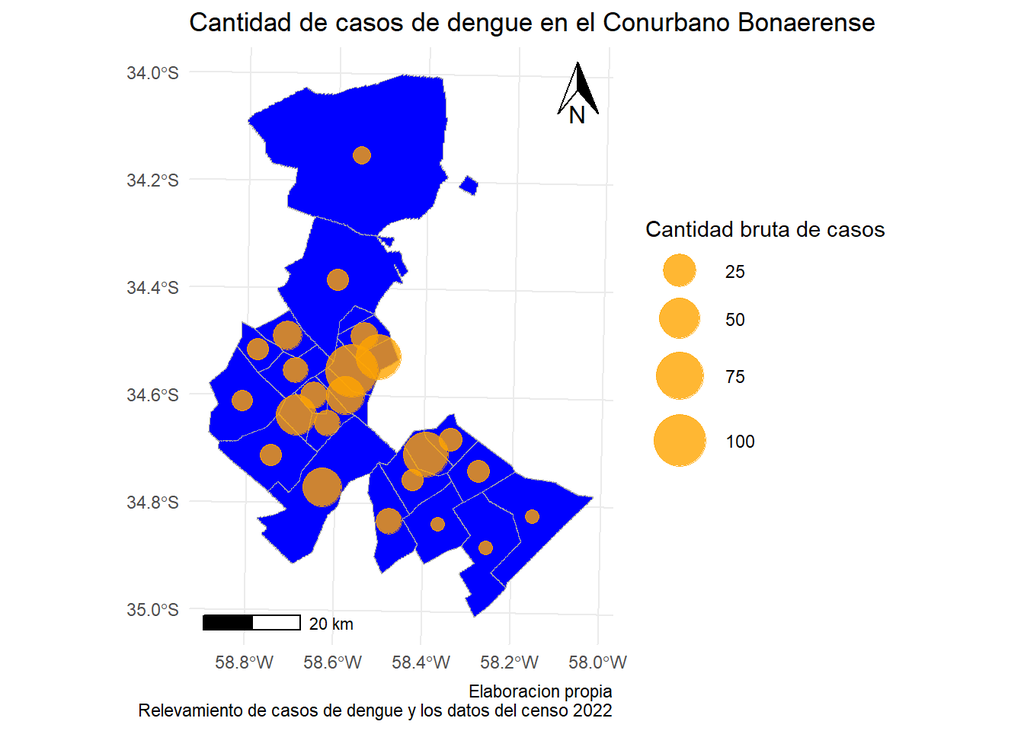

```r
# casos absolutos del dengue
# correccion de geometrias inválidas y el calculo del centroide de la geometría
mapa_centroides <- mapa_dengue |>
  st_make_valid() |>
  st_centroid()

mapa_casos <- ggplot() +
  geom_sf(data = mapa_dengue, fill = "blue", color = "darkgray", size = 0.2) +
  geom_sf(data = mapa_centroides, aes(size = Casos_dengue), color = "orange", alpha = 0.8) +
  scale_size_continuous(name = "Cantidad bruta de casos", range = c(3, 12)) +
  annotation_scale(
    location = "bl"
  ) +
  annotation_north_arrow(
    location = "tr",
    height = unit(1, "cm"),
    width = unit(0.7, "cm")
  ) +
  labs(
    title = "Cantidad de casos de dengue en el Conurbano Bonaerense",
    caption = "Elaboracion propia\nRelevamiento de casos de dengue y los datos del censo 2022"
  ) +
  theme_minimal()

print(mapa_casos)
```

```r
ggsave("graficos/mapa_casos.jpg", plot = mapa_casos, width = 10, height = 8, dpi = 300)
```

En este caso (Figura/Mapa 1) encontramos a ciertos municipios, con grandes cantidades de casos confirmados de dengue. Prosiguiendo con la lógica de los primeros 5 municipios con más casos encontramos que:

1. General San Martín: 103 casos.
2. Lanús y Vicente López: 65 casos cada uno.
3. Ituzaingó: 48 casos.
4. La Matanza: 44 casos.

# Figura/Mapa 2:

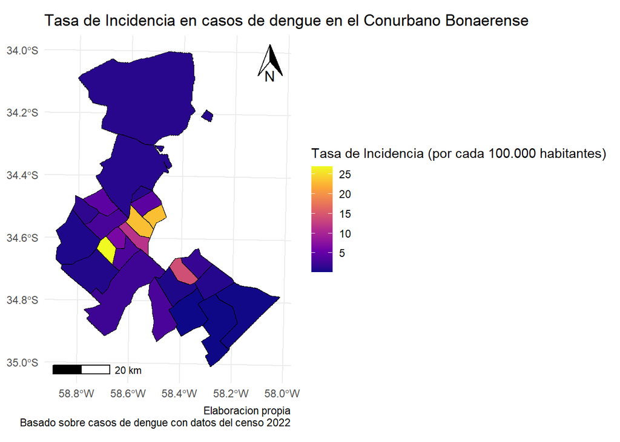

```r
#coropleta
mapa_coropleta <- ggplot(data = mapa_dengue) +
  geom_sf(aes(fill = Tasa_Incidencia_100000), color = "black", size = 0.2) +
  scale_fill_viridis_c(option = "plasma", name = "Tasa de Incidencia (por cada 100.000 habitantes)") +
  annotation_scale(
    location = "bl"
  ) +
  annotation_north_arrow(
    location = "tr",
    height = unit(1, "cm"),
    width = unit(0.7, "cm")
  ) +
  labs(
    title = "Tasa de Incidencia en casos de dengue en el Conurbano Bonaerense",
    caption = "Elaboracion propia\nBasado sobre casos de dengue con datos del censo 2022"
  ) +
  theme_minimal()

print(mapa_coropleta)
```

```r
ggsave("graficos/mapa_coropleta.jpg", plot = mapa_coropleta, width = 10, height = 8, dpi = 300)
```

A la hora de visualizar el Figura/Mapa 2 notamos ciertos comportamientos distintos a los que nos propone el mapa con los casos confirmados. En este caso podemos notar ciertas particularidades:

Veamos ahora que propone el mapa interactivo, que permite unificar toda la información importante referente a los casos de dengue. En este caso interactúan datos como el nombre del municipio, la tasa de Incidencia de casos y la cantidad bruta de los casos.

# Grafico 1:

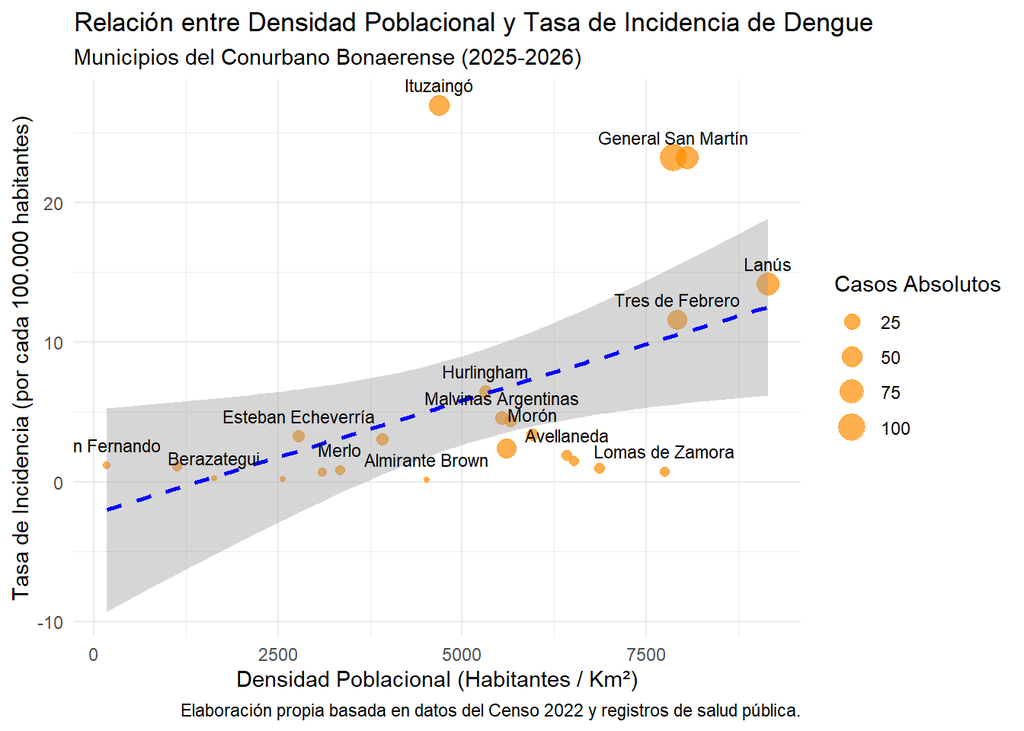

```r
# Grafico de dispersion para cruzar Densidad y Tasa de Incidencia
grafico_correlacion <- ggplot(data = df_resultado, aes(x = Densidad_Hab_Km2, y = Tasa_Incidencia_100000)) +
  geom_point(aes(size = Casos_dengue), color = "darkorange", alpha = 0.7) +
  geom_smooth(method = "lm", color = "blue", se = TRUE, linetype = "dashed") +
  geom_text(aes(label = Municipio), vjust = -1, size = 3, check_overlap = TRUE) +
  labs(
    title = "Relación entre Densidad Poblacional y Tasa de Incidencia de Dengue",
    subtitle = "Municipios del Conurbano Bonaerense (2025-2026)",
    x = "Densidad Poblacional (Habitantes / Km²)",
    y = "Tasa de Incidencia (por cada 100.000 habitantes)",
    size = "Casos Absolutos",
    caption = "Elaboración propia basada en datos del Censo 2022 y registros de salud pública."
  ) +
  theme_minimal()

print(grafico_correlacion)
```

```r
ggsave("graficos/grafico_correlacion.jpg", plot = grafico_correlacion, width = 9, height = 7, dpi = 300)
```

Como se describe en el Gráfico 1, uniendo las variables de Densidad Poblacional y Tasa de Incidencia, notamos como los casos de Ituzaingó está en la cima, liderando la tasa, y no siendo de los más densamente poblados; los casos como los de General San Martín, de considerable densidad poblacional, sumado a una tasa de Incidencia importantes; por último, los casos como el de Lomas de Zamora, no son los que se corresponde con la tasa, siendo de considerable densidad poblacional.

# Gráfico 2:

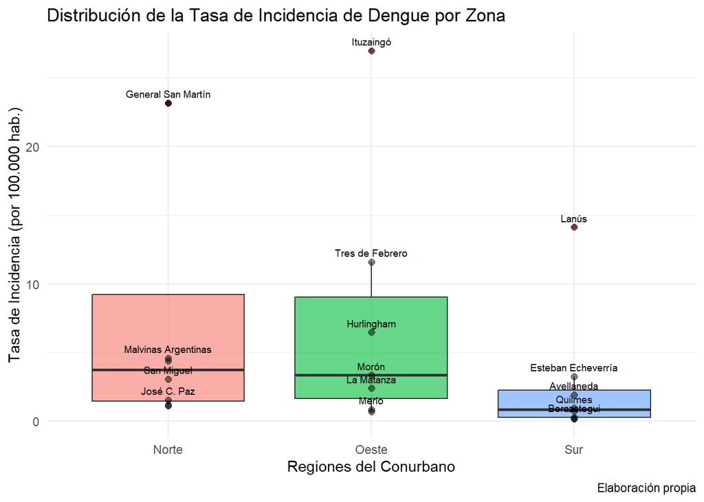

```r
# 1. Creamos una clasificación rápida por zonas (ejemplo con algunos municipios de tu análisis)
df_resultado_zonas <- df_resultado |>
  mutate(Zona = case_match(
    Municipio,
    "Vicente López" ~ "Norte",
    "Tigre" ~ "Norte",
    "San Fernando" ~ "Norte",
    "San Isidro" ~ "Norte",
    "San Miguel" ~ "Norte",
    "Malvinas Argentinas" ~ "Norte",
    "José C. Paz" ~ "Norte",
    "General San Martín" ~ "Norte",
    "Tres de Febrero" ~ "Oeste",
    "Morón" ~ "Oeste",
    "Merlo" ~ "Oeste",
    "Moreno" ~ "Oeste",
    "Hurlingham" ~ "Oeste",
    "Ituzaingó" ~ "Oeste",
    "La Matanza" ~ "Oeste",
    "Lanús" ~ "Sur",
    "Lomas de Zamora" ~ "Sur",
    "Avellaneda" ~ "Sur",
    "Almirante Brown" ~ "Sur",
    "Quilmes" ~ "Sur",
    "Berazategui" ~ "Sur",
    "Florencio Varela" ~ "Sur",
    "Esteban Echeverría" ~ "Sur",
  ))

# 2. Gráfico de Cajas
grafico_cajas <- ggplot(df_resultado_zonas, aes(x = Zona, y = Tasa_Incidencia_100000, fill = Zona)) +
  geom_boxplot(alpha = 0.6, outlier.color = "red", outlier.shape = 16) +
  geom_point(size = 2, alpha = 0.5) + # Muestra los municipios como puntos individuales
  geom_text(aes(label = Municipio),
            vjust = -0.7,
            size = 2.5,
            check_overlap = TRUE) +
  labs(
    title = "Distribución de la Tasa de Incidencia de Dengue por Zona",
    x = "Regiones del Conurbano",
    y = "Tasa de Incidencia (por 100.000 hab.)",
    caption = "Elaboración propia"
  ) +
  theme_minimal() +
  theme(legend.position = "none")

print(grafico_cajas)
```

```r
ggsave("graficos/grafico_cajas.jpg", plot = grafico_cajas, width = 9, height = 7, dpi = 300)
```

Si empezamos a establecer los bloques o regiones del Conurbano en Norte, Oeste y Sur, notamos los valores atípicos o outliers destacados como veniamos analizando: los casos de Ituzaingó, General San Martín, o Lanús. Algo que se verá más en su totalidad en el mapa interactivo siguiente.

# Figura/Mapa 3:

```r
# mapa leaflet interactivo
# si o si st_transform sino el mapa leaflet aparece en cualquier lado
# 1. Definición de la paleta de colores
pal <- colorNumeric(palette = c("seagreen4", "deeppink4"), domain = mapa_dengue$Tasa_Incidencia_100000)

# 2. Creación del mapa interactivo con todos sus componentes cartográficos
mapa_interactivo <- mapa_dengue |>
  st_transform(4326) |>
  leaflet() |>
  addTiles() |>
  addPolygons(
    color = ~pal(Tasa_Incidencia_100000),
    popup = ~paste0("<b>Municipio:</b> ", Municipio, "<br>",
                    "<b>Tasa:</b> ", round(Tasa_Incidencia_100000, 1), "<br>",
                    "<b>Casos confirmados:</b> ", Casos_dengue),
    label = ~Municipio,
    fillOpacity = 0.7,
    weight = 1
  ) |>

  # --- A. AGREGAR ESCALA GRÁFICA ---
  addScaleBar(
    position = "bottomleft",
    options = scaleBarOptions(metric = TRUE, imperial = FALSE)
  ) |>

  # --- B. AGREGAR TÍTULO (Usando código HTML) ---
  addControl(
    html = "<div style='background: rgba(255,255,255,0.8); padding: 8px; border-radius: 5px;'>
              <h3 style='margin:0; font-family: Arial, sans-serif;'>Tasa de Incidencia de Dengue</h3>
              <p style='margin:2px 0 0 0; font-size:12px; color:#555;'>Conurbano Bonaerense (2025-2026)</p>
            </div>",
    position = "topright"
  ) |>

  # --- C. AGREGAR EPÍGRAFE / CAPTION ---
  addControl(
    html = "<div style='background: rgba(255,255,255,0.7); padding: 4px; font-size: 10px; font-family: Arial;'>
              <b>Elaboración propia</b><br>Basado en casos de dengue y datos del Censo 2022
            </div>",
    position = "bottomright"
  ) |>

  # --- D. AGREGAR LA LEYENDA DE COLORES ---
  addLegend(
    pal = pal,
    values = ~Tasa_Incidencia_100000,
    opacity = 0.7,
    title = "Tasa (por 100k hab.)",
    position = "bottomleft"
  ) |>

  # --- E. AGREGAR FLECHA DEL NORTE (HTML Puro) ---
  addControl(
    html = "<div style='font-family: Arial, sans-serif; font-size: 24px; font-weight: bold; color: #333; text-align: center; background: rgba(255,255,255,0.7); padding: 2px 8px; border-radius: 5px;'>
              <span style='display: block; transform: rotate(0deg); line-height: 1;'>↑</span>
              <span style='font-size: 11px; display: block; margin-top: -2px;'>N</span>
            </div>",
    position = "topleft"
  )

# Mostrar el mapa en el Rmd
mapa_interactivo
```

[interactive chart not shown]

# Conclusiones:

Finalizando este trabajo de investigación pudimos revisar los datos correspondientes a casos de dengue y la densidad poblacional. Con ello encontramos algunas consideraciones:

Volviendo a la hipótesis: “Los 5 municipios más densamente poblados del Conurbano Bonaerense (Lanús, Vicente López, Tres de Febrero, General San Martín, Lomas de Zamora) revisten las más altas tasas de Incidencia de casos de dengue durante el período 2025-2026”, podemos aducir que no es correcto este enunciado.

Si bien los municipios de Vicente López, Gral. San Martín son aquellos que no solo contienen cantidades importantes de casos sobre dengue, son los que conforman el grupo de los más densamente poblados y los que tienen mayores tasas de Incidencia, no sucede de la misma forma para los partidos de Lanús y Tres de Febrero (que tienen menores tasas de Incidencia); sumado al caso de Lomas de Zamora donde no refleja esta situación (muy baja tasa de Incidencia y de casos confirmados de dengue).

# Referencias:

Ministerio de Salud de la Nación. (2024). Resumen ejecutivo: Plan de preparación y respuesta integral a epidemias de dengue y otras enfermedades arbovirales. Argentina.gob.ar. https://www.argentina.gob.ar/sites/default/files/2024/08/2025-10-resumen-ejecutivo-plan-preparacion-arbovirus-1310.pdf

Ministerio de Salud de la Nación. (2026). Vigilancia de Dengue y Zika (Se 1 2025 - Se 20 2026) [Conjunto de datos]. Portal de Datos Abiertos Salud. https://datos.salud.gob.ar/dataset/vigilancia-de-dengue-y-zika/archivo/33e12e9f-1d14-4bc7-b34c-a1f88ab7b990

Pablo De Grande y Agustín Salvia (2024). Indicadores del Censo Nacional de Población, Hogares y Viviendas, 2022. Recuperado el 22 de junio, 2026, de https://poblaciones.org/@257701

Programa de Estudios del Conurbano. (2016). Conurbano. Atlas del Conurbano Bonaerense; Universidad Nacional de Avellaneda. https://www.atlasconurbano.info/pagina.php?id=169

Ruiz Nicolini J, Del Boca P, Juara J (2024). geoAr: Argentina’s Spatial Data Toolbox. R package version 1.0.0, https://github.com/PoliticaArgentina/geoAr.